# Intro to Shiny Apps

Elisa Schneider for R-Ladies Freiburg  
August 11, 2020

[figure not shown]

[figure not shown]

### Shiny Gallery

[figure not shown]

### Architecture of a Shiny App

Let's have a look at one (not so simple) shiny app

[figure not shown]

### Architecture of a Shiny App

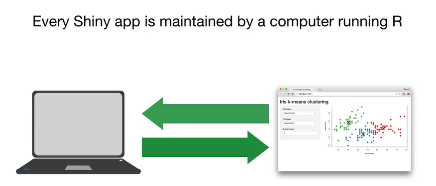

### App template

The simplest viable shiny app

```r
ui <- fluidPage()

server <- function(input, output) {}

shinyApp(ui = ui, server = server)
```

### Let's look at the code behind the shiny app

[figure not shown]

All shiny apps have

- **ui** function that defines how the user interface looks like and what the user can do in that interface.
- **server** function where R-Code runs and returns the utput to the **ui**.

### Page Set Up - User Interface

**00-User-interface/App.R**

```r
library(shiny)
ui <- fluidPage(
  titlePanel("title panel"),
  sidebarLayout(
    sidebarPanel("sidebar panel"),
    mainPanel("main panel")
  )
)
server <- function(input, output) {
}
# Return a Shiny app object
shinyApp(ui = ui, server = server)
```

[More on layouts here](https://shiny.rstudio.com/articles/layout-guide.html)

**Fluid Page View**

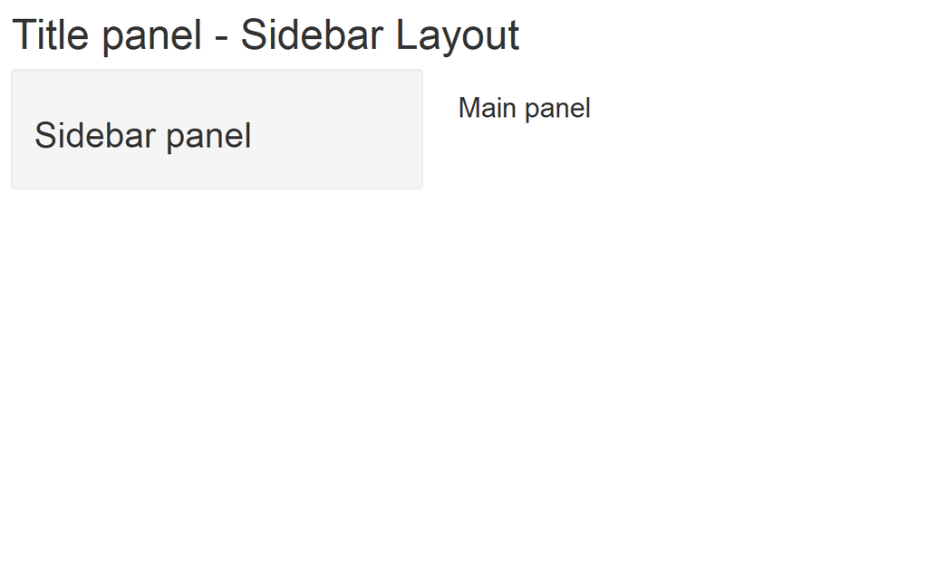

### Data Flow Structure

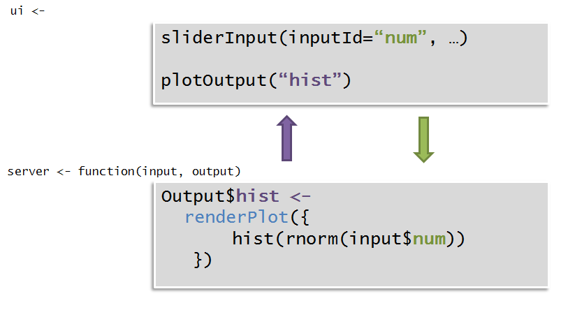

### Inputs - Structures

Access input values with `Input$`

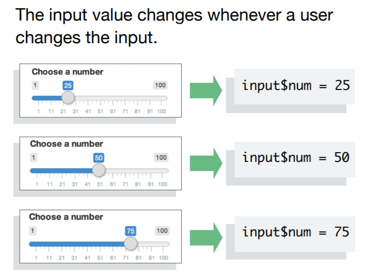

### Inputs - Basic Widgets

Funtions

- `actionButton`
- `checkboxInput`
- `checkboxGroupInput`
- `dateInput`
- `dateRangeInput`
- `fileInput`
- `helpText`
- `numericInput`
- `radioButtons`
- `selectInput`
- `sliderInput`
- `textInput`

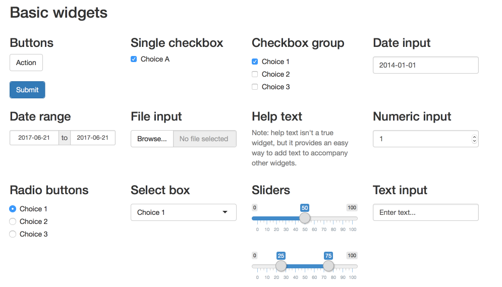

### Inputs - Simpler example

**01-simplest-example/App.R**

```r
library(shiny)
# Global variables can go here
n <- 200
# Define the UI
ui <- fluidPage(
  titlePanel("Simplest Shiny App"),
  sidebarLayout(
    sidebarPanel(
      numericInput(inputId = 'n',
               label = 'Number of obs',
               value = n)
      ),
    mainPanel(plotOutput("myPlot"))
  )
)
# Define the server code
server <- function(input, output) {
}
# Return a Shiny app object
shinyApp(ui = ui, server = server)
```

### Making the App Reactive - Outpus

Show output values with `render`

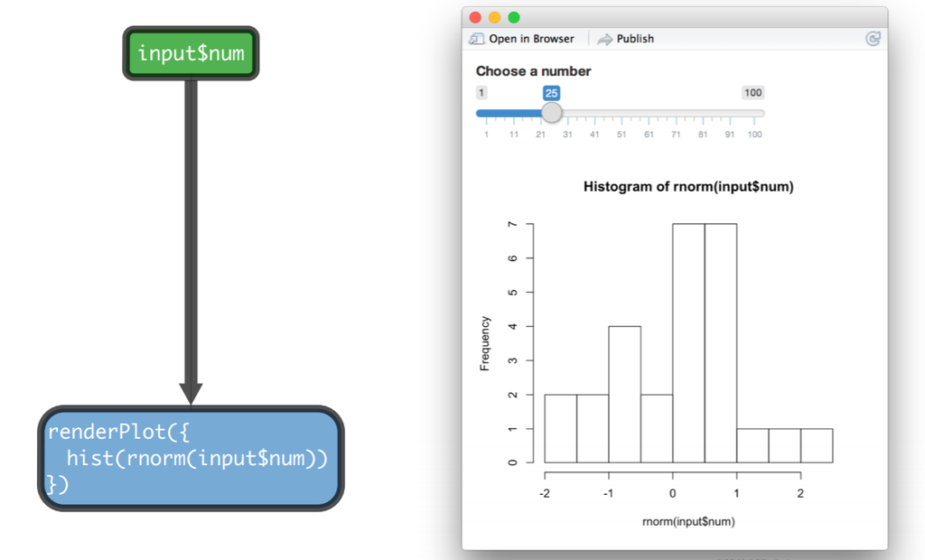

### Build Objects to display with render*()

Render Functions

- `renderTable`
- `renderPlot`
- `renderText`
- `renderUI`
- `renderImage`

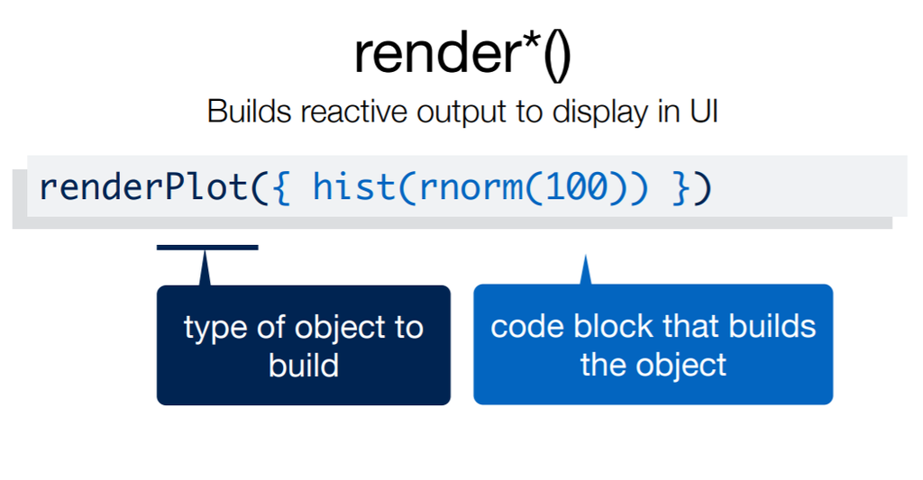

### Build Objects to display with render*()

```r
# Server function

server <- function(input, output) {

  title <- "Normal distribution"
  xlabel <- "Value"

  output$hist <- renderPlot({
    hist(rnorm(input$n), main = title, xlab = xlabel)
  })
}
```

### Showing the output in the user interface - output functions

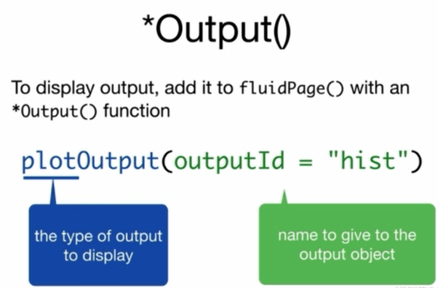

### Making the App reactive - Outpus

**01-simplest-example/App.R**

```r
library(shiny)
# Global variables can go here
n <- 50
# Define the UI
ui <- fluidPage(
  titlePanel("Simplest Shiny App"),
  sidebarLayout(
    sidebarPanel(
       sliderInput(inputId = "n",
                   label = "Number of obs",
                   min = 0,
                   max = 100,
                   value = n),
    mainPanel(plotOutput("hist"))
  )
)
# Define the server code
server <- function(input, output) {
  title <- "Normal distribution"
  xlabel <- "Value"
  output$hist <- renderPlot({
    hist(rnorm(input$n), main = title, xlab = xlabel)
  })
}

# Return a Shiny app object
shinyApp(ui = ui, server = server)
```

### Recap

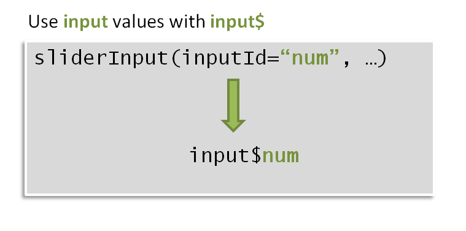

### Recap

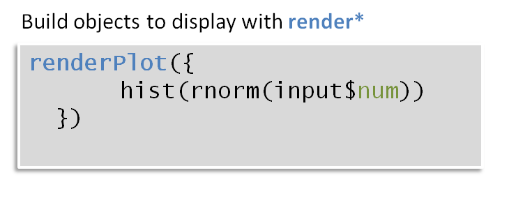

### Recap

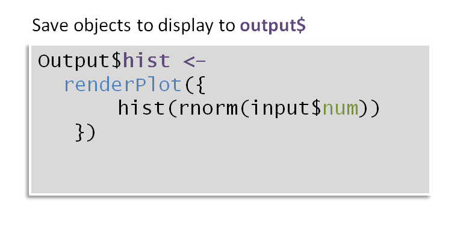

### Recap

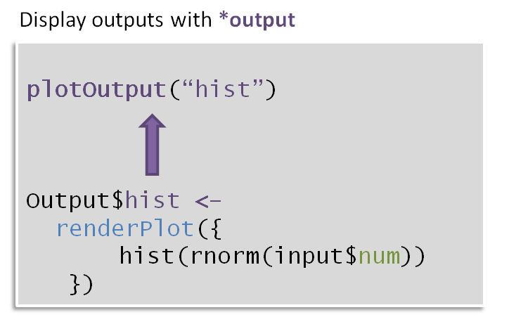

### Recap

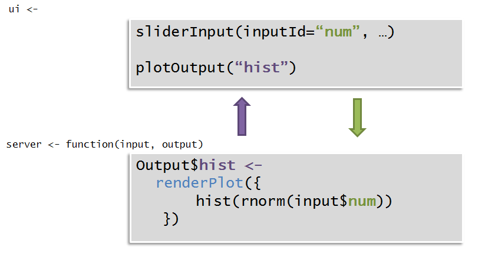

### Showing the output in the user interface - output functions

**03-Hello/App.R**

```r
library(shiny)
# Define UI for application that draws a histogram
ui <- fluidPage(
   # Application title
   titlePanel("Old Faithful Geyser Data"),
   # Sidebar with a slider input for number of bins
   sidebarLayout(
      sidebarPanel(
         textInput(inputId = "text",
                     label = "Write what you want, you do not have to be creative",
                     value = "")
      ),
      # Show a plot of the generated distribution
      mainPanel(
         textOutput("user_text")
      )
   )
)
# Define server logic
server <- function(input, output) {
output$user_text <- renderText({
  paste("This shows what you are wrinting: " , input$text)
})
}
# Run the application
shinyApp(ui = ui, server = server)
```

### Hands on example

### Share our Shiny Apps

- Use a folder that contains all what your app needs (data, images, css) plus the shiny file with the name app.R
- Shinyapps.io - Server mantained by RStudio. Only loading the app into the server is required. You have to create an account. [get started here](https://shiny.rstudio.com/articles/shinyapps.html#:%7E:text=Go%20to%20shinyapps.io%20and,name%20for%20all%20your%20apps.)
- Shiny server for your own server - Free and open source (Free except for the Pro version)

### What can we learn to do great shiny apps?

[figure not shown]

- Intro to Shiny Apps
- Reactivity in shiny apps
- Customize appearance

### Resources used for this presentation and to go on learning

- [Shiny gallery](https://shiny.rstudio.com/gallery/)
- [Intro so shiny - video (intro + reactivity + custoimzation)](https://shiny.rstudio.com/tutorial/)
- [Written tutorials](https://shiny.rstudio.com/tutorial/written-tutorial/lesson1/)
- [Layout](https://shiny.rstudio.com/articles/layout-guide.html)
- [Reactivity](https://rstudio.com/resources/shiny-dev-con/reactivity-pt-1-joe-cheng/)

### Basic customisation

**02-HTML-formating/App.R**

```r
library(shiny)
ui <- fluidPage(
  titlePanel("My Shiny App"),
  sidebarLayout(
    sidebarPanel(h3("The sidebar panel")),
    mainPanel(
      p("p creates a paragraph of text."),
      p("A new p() command starts a new paragraph. Supply a style attribute to change the format of the entire paragraph.", style = "font-family: 'times'; font-si16pt"),
      strong("strong() makes bold text."),
      em("em() creates italicized (i.e, emphasized) text."),
      br(),
      code("code displays your text similar to computer code"),
      div("div creates segments of text with a similar style. This division of text is all blue because I passed the argument 'style = color:blue' to div", style = "color:blue"),
      br(),
      p("span does the same thing as div, but it works with",
        span("groups of words", style = "color:blue"),
        "that appear inside a paragraph.")
      # img(src = "RLadies.jpg)
    )
  )
)
# Define server logic required to draw a histogram
server <- function(input, output) {
}

# Run the application
shinyApp(ui = ui, server = server)
```